# Analysis of UK road safety data

19/12/2021

## 1. Analysis based on Age bands and casualty class (2016 - 2020)

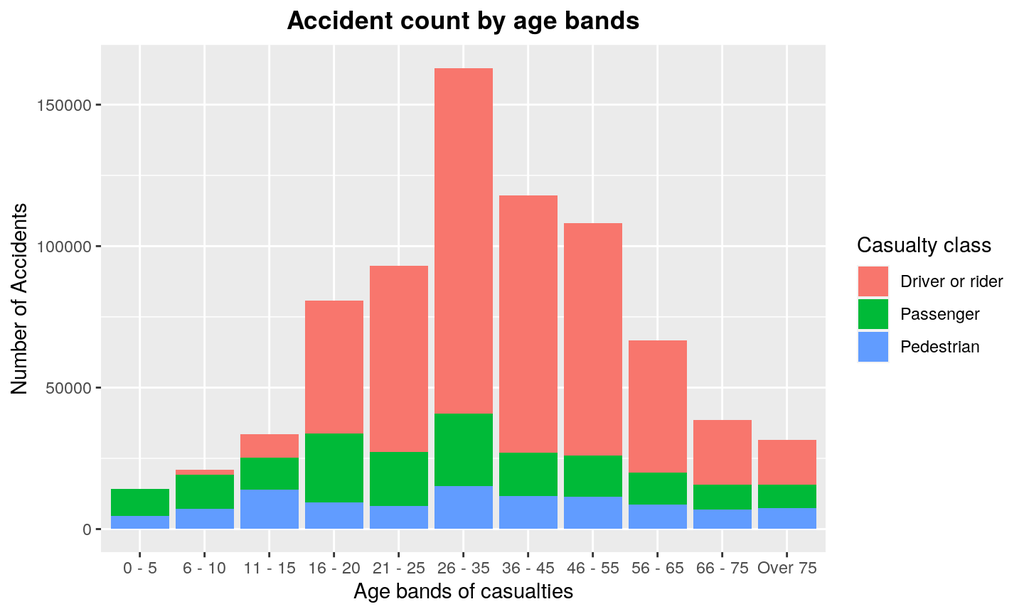

## 1. Analysis based on Age bands and casualty class (2016 - 2020)

- Three casualty classes - Driver/rider, Passenger, Pedestrian
- Number of casualties highest in age band 26-35, followed by 36-45
- Most casualties above 18 years of age are drivers/riders
- Driving test should be intensified for the age-groups with highest casualties
- Usage of public transport must be encourage and rules governing private ownership of vehicles must be stringent

## 2. Analysis based on severity

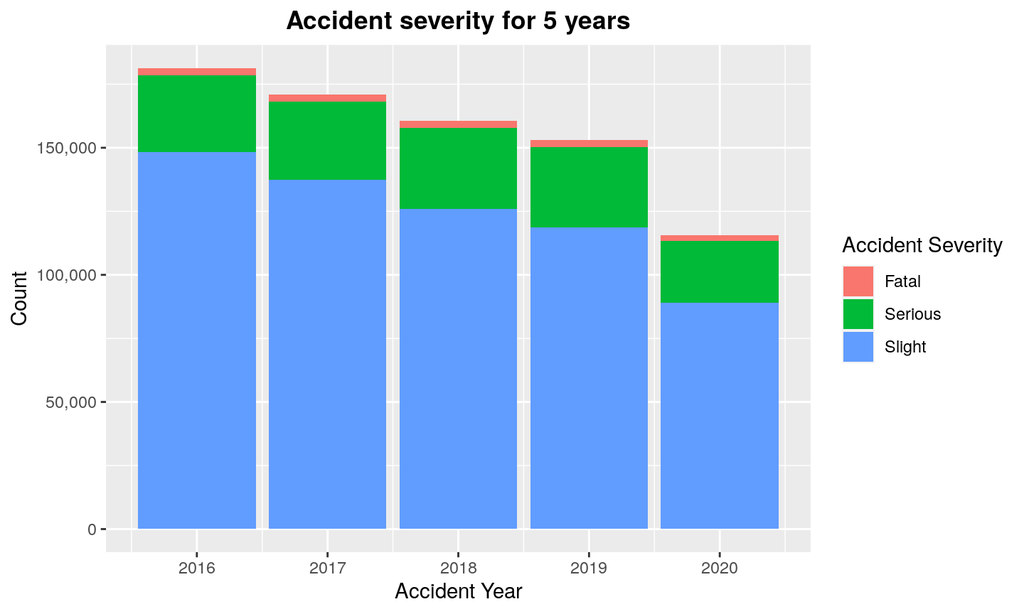

## 3. Number of accidents every hour per week day (2016-2020)

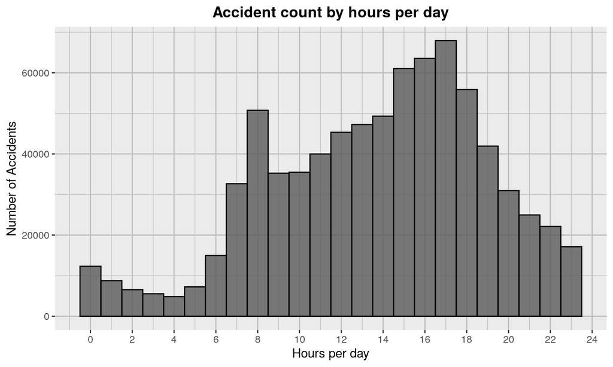

## 3. Number of accidents every hour per week day (2016-2020)

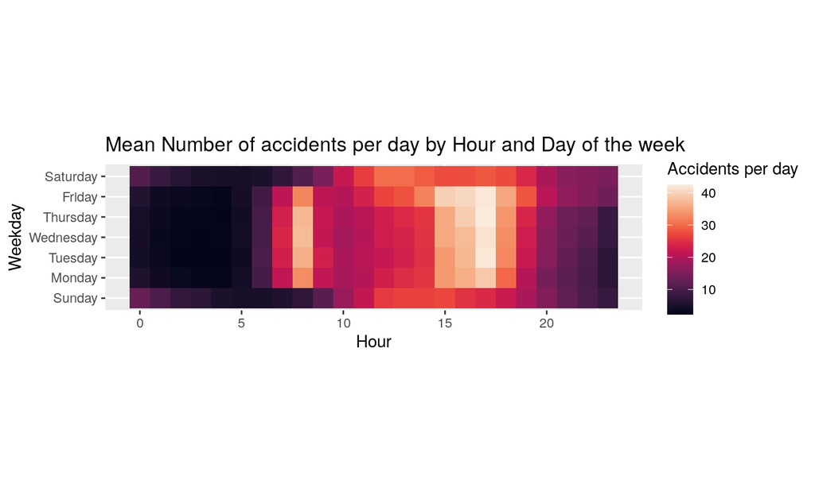

## 3. Number of accidents every hour per week day (2016-2020)

- Casualties peak during start and end of working hours, i.e., 08:00 and from 15:00 - 18:00
- Minimum during early mornings and nights
- Road users should be alerted, stricter Road Traffic Police patrolling during busy hours
- Can be observed that highest number of casualties is during weekdays (Mon-Fri)
- > 35 accidents per day at time 17:00 during weekdays

## 4. Road type and speed limit

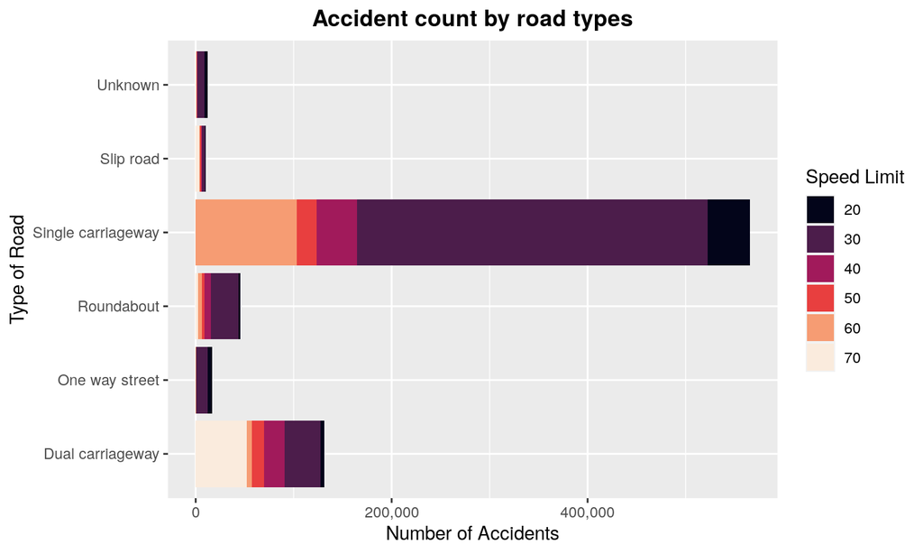

## 4. Road type and speed limit

- maximum accidents with casualties occur in single carriageways with speed limit 30mph
- Mostly because of lack of lane dividers and/or insufficient light
- second maximum accident count in dual carriageways, speed limit 70 mph
- Solutions: Prompt accident response, improved visibility of signs and reflectors

## 5. Accident factors

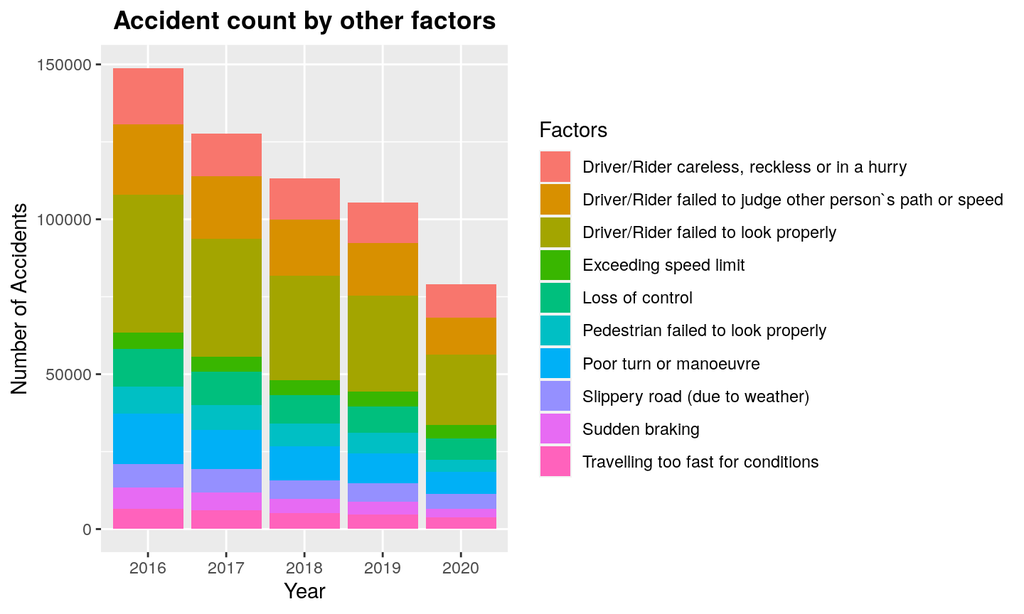

## 5. Accident factors

- Most accidents due to drivers failing to look properly
- Followed by drivers who failed to judge other person’s path
- Total count decreasing over the years